# L1 contraint learning of submodular mixtures

## Method

In this work, we propose a novel formulation for learning submodular mixture weights. It is an extension of [1], where the problem is formulated as:

$\underset{\mathbf{w}\geq 0}{\min}\frac{1}{T}\sum_{t=1}^{T}\hat{L}_t(\mathbf{w}) + \frac{\lambda}{2}||\mathbf{w}||^2.$

Rather than minimizing the $l_2$-norm as [1], we propose an $l_1$-constraint minimization, i.e.

$ \underset{\mathbf{w}\geq 0}{\min}\frac{1}{T}\sum_{t=1}^{T}\hat{L}_t(\mathbf{w}) \\ \text{s.t.} \sum_{i=1}^{n}w_i \leq 1, w_i \geq 0 \forall i $

where the loss function is defined as [1]:

$ \hat{L}_t(\mathbf{w}) = \underset{\mathbf{y}\subseteq \mathbf{Y_V}^{(t)}}{\max} ( \mathbf{w}^\mathrm{T}\mathbf{f}(\mathbf{x}_\mathbf{V}^{(t)},\mathbf{y}) + l_t(\mathbf{y}) ) - \mathbf{w}^\mathrm{T}\mathbf{f}(\mathbf{x}_\mathbf{V}^{(t)},\mathbf{y}_\text{gt}^{(t)}), $

In order to minimize this problem, we follow [1] and use stochastic subgradient descent. In [1], the $w_t$ is projected back into the feasable set using $\mathbf{w_t}=max(\mathbf{0,w_{t-1}}-\eta_t\mathbf{g_t})$. Instead, we project it back into the $l_1$-semiball, by solving the following optimization problem:

$ \mathbf{w_t}=\underset{\mathbf{w_t}}{\arg\min}\left(||\mathbf{w_t}-(\mathbf{w_{t-1}}-\eta_t\mathbf{g_t})||^2_2\right) \\\text{s.t.} \sum_{i=1}^{n}w_i \leq 1, w_i \geq 0 \forall i %FIXME: currently we normalize the wegihts to sum to one afterwards: w[it]=w[it]/np.sum(w[it]). remove? or use it as a constraint in the optimization? $

By projecting the learnt weights into the $l_1$-semiball, our approach learns sparser weights, which makes it more robust to noise. In the following we present a set of simple experiments, comparing the proposed method to [1].

[1] Lin, H. & Bilmes, J. Learning mixtures of submodular shells with application to document summarization. UAI 2012

[2] Leskovec, J., Krause, A., Guestrin, C., Faloutsos, C., VanBriesen, J., & Glance, N. Cost-effective outbreak detection in networks. ACM SIGKDD 2007

[3] Gygli, M., Grabner, H., & Gool, L. Van. Video Summarization by Learning Submodular Mixtures of Objectives. CVPR 2015

## Experiments

We evaluate our method on a simple toy dataset. Thereby we proceed as follows:

1. We create a dataset of random points in 2D (see Figure below).
2. We define a set of submodular objectives each with a predefined weight.
3. Obtain ground truth by optimizing the objectives using [2].

Given this data, we use our own and the method of [1] to reconstruct/learn the weights. The error in reconstructing the initial weights serves as a performance metric. As a loss function we use a 1-minus intersection loss:

$ l_t(\mathbf{y}) = \frac{1}{B}\left(\left\vert{ \mathbf{y} }\right\vert - \left\vert{ \mathbf{y} \cap \mathbf{y}_\text{gt}^{(t)} }\right\vert\right) $

i.e. it is a count of how many of the candidate summary y are not represented in the ground truth, normalized by the maximal length of the summary [3].

### Objectives

We use two objectives, a k-medoid scoring [3] and a simple modular objective, which uses sum of x coordinates of a solution (examples: see below).

As a noise objective, we further assign each datapoint a random score and use the sum over these scores.

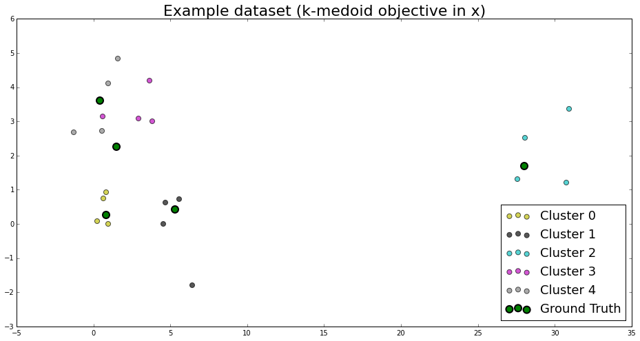

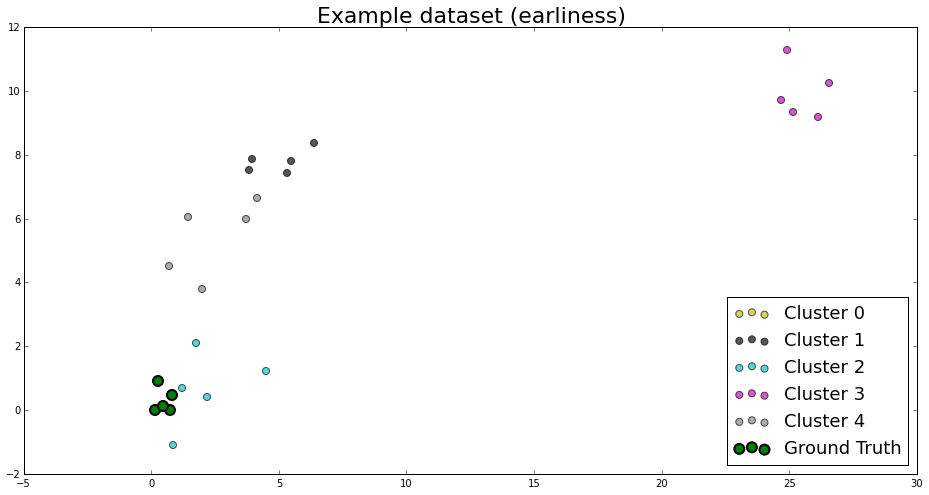

```python
## This is how an example training sample looks like
import subm_tests
reload(subm_tests.gm_submodular)
reload(subm_tests.ex)
reload(subm_tests.tp)
reload(subm_tests)
%matplotlib inline
S_list,shells,weights_gt=subm_tests.createTrainingData(num_datasets=1,weights=[1,0])
t='Example dataset (k-medoid objective in x)'
subm_tests.plotExample(S_list[0],weights=weights_gt,title=t,objectives=map(lambda x: x(S_list[0]),shells))
import matplotlib.pyplot as plt
plt.figure()
S_list,shells,weights_gt=subm_tests.createTrainingData(num_datasets=1,weights=[0,1])
t='Example dataset (earliness)'
subm_tests.plotExample(S_list[0],weights=weights_gt,title=t,objectives=map(lambda x: x(S_list[0]),shells))
```

```python
# Some initialization
subm_tests.gm_submodular.logger.setLevel(subm_tests.gm_submodular.logging.ERROR)
num_runs=100
```

```
testing range 0.0, 0.2, 0.4, 0.6, 0.8, 1.0
l1-ball: 0.0075203225; lin: 0.0228394777; adagrad: 0.0063343714
l1-ball: 0.0135122223; lin: 0.0216081818; adagrad: 0.0140602086
l1-ball: 0.0129936705; lin: 0.0169346011; adagrad: 0.0136990454
l1-ball: 0.0127378550; lin: 0.0158748412; adagrad: 0.0128483782
l1-ball: 0.0130829639; lin: 0.0151129934; adagrad: 0.0118582472
l1-ball: 0.0145430340; lin: 0.0149627131; adagrad: 0.0165312868
```

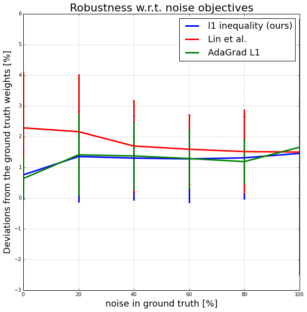

```python
# Test how the methods are affected by having noise in the ground truth
gt_variability,l1_error,lin_error=subm_tests.get_noisy_ground_truth_plot(num_runs)
```

```
testing range 0, 1, 2, 3, 4
l1-ball: 0.0089231478; lin: 0.0255318921; adagrad: 0.0048150187
l1-ball: 0.0194767171; lin: 0.0493172872; adagrad: 0.0111206677
l1-ball: 0.0363279657; lin: 0.0808131251; adagrad: 0.0196861681
l1-ball: 0.0605040451; lin: 0.1197807655; adagrad: 0.0260488670
l1-ball: 0.0897243582; lin: 0.1658685988; adagrad: 0.0380466729
```

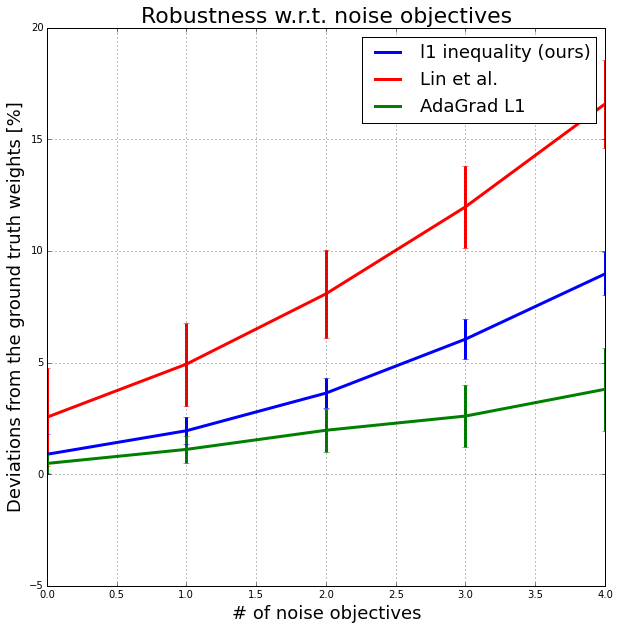

```python
# Test how the methods are affected by objectives that only contribute noise
num_noise_obj,l1_error,lin_error=subm_tests.get_noisy_objective_plot(num_runs)
```

### Test how accurately the methods learn a combination of objectives (witohut any noise objectives)

```
testing ratios 0.0, 0.1, 0.2, 0.3, 0.4, 0.5, 0.6, 0.7, 0.8, 0.9, 1.0
l1-ball: 0.0082914501; lin: 0.0223832579; adagrad: 0.0049514179
l1-ball: 0.0814469922; lin: 0.1220903284; adagrad: 0.0953594148
l1-ball: 0.1264148439; lin: 0.1534120238; adagrad: 0.0551538356
l1-ball: 0.1673023490; lin: 0.1835121632; adagrad: 0.0534418076
l1-ball: 0.1898590359; lin: 0.1851800561; adagrad: 0.0821398050
l1-ball: 0.2047146713; lin: 0.1669605093; adagrad: 0.1350885332
l1-ball: 0.4729981336; lin: 0.2760748873; adagrad: 0.3085082173
l1-ball: 0.5507412873; lin: 0.3447937164; adagrad: 0.4284323752
l1-ball: 0.3982682244; lin: 0.3472894311; adagrad: 0.3829833269
l1-ball: 0.2000000253; lin: 0.1995716424; adagrad: 0.1995397210
l1-ball: 0.0003533272; lin: 0.0193142542; adagrad: 0.0036400247
```

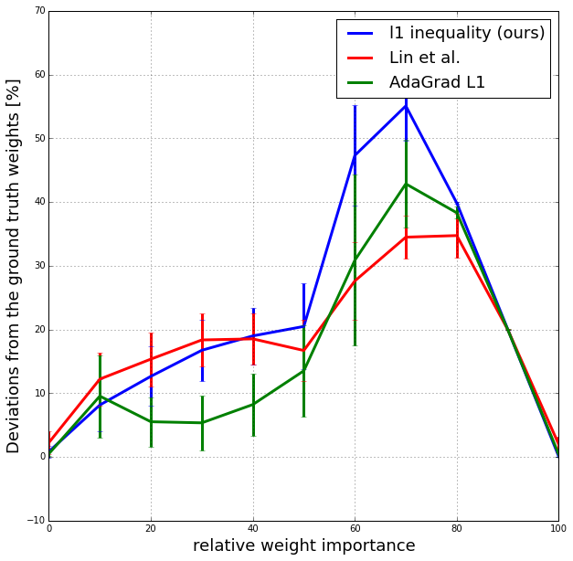

```python
obj_ratio,l1_error,lin_error=subm_tests.get_multiobjective_plot(num_runs,num_noise_obj=0)
```

```
testing ratios 0.0, 0.1, 0.2, 0.3, 0.4, 0.5, 0.6, 0.7, 0.8, 0.9, 1.0
l1-ball: 0.0194039514; lin: 0.0473800664; adagrad: 0.0109538212
l1-ball: 0.0698112187; lin: 0.1572776845; adagrad: 0.0843832791
l1-ball: 0.1206307018; lin: 0.1906773865; adagrad: 0.0531810559
l1-ball: 0.1675953637; lin: 0.2118295472; adagrad: 0.0665852427
l1-ball: 0.1940032299; lin: 0.2059345180; adagrad: 0.0959882513
l1-ball: 0.2067760666; lin: 0.1830626872; adagrad: 0.1286941171
l1-ball: 0.4611888678; lin: 0.2907989173; adagrad: 0.2983282804
l1-ball: 0.5468560022; lin: 0.3519648404; adagrad: 0.4381930232
l1-ball: 0.3976064867; lin: 0.3532170541; adagrad: 0.3785754144
l1-ball: 0.1999949101; lin: 0.1994803463; adagrad: 0.1990932226
l1-ball: 0.0022699642; lin: 0.0884247141; adagrad: 0.0188097674
```

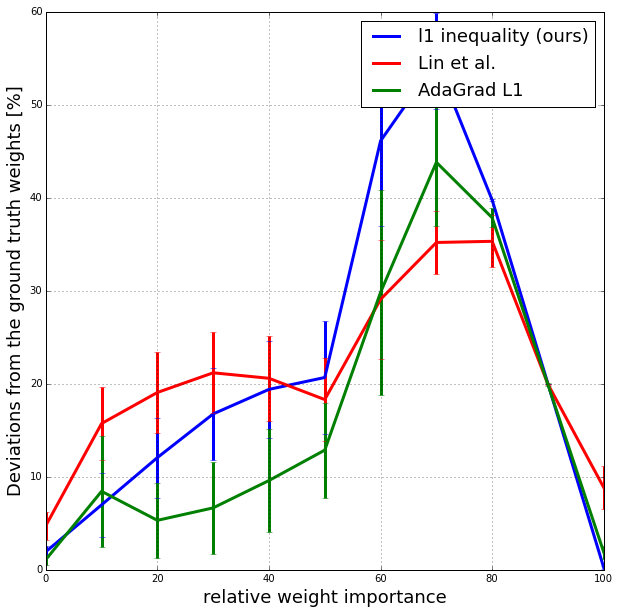

```python
# Test how accurately the methods learn a combination of objectives (under inclusing of 1 noise objective)
reload(subm_tests.gm_submodular)
reload(subm_tests)
subm_tests.gm_submodular.logger.setLevel(subm_tests.gm_submodular.logging.ERROR)
obj_ratio,l1_error,lin_error=subm_tests.get_multiobjective_plot(num_runs,num_noise_obj=1)
```